# Topic 7-01: GSEA framework

Zuguang Gu z.gu@dkfz.de

2025-05-25

```r
lt = readRDS(system.file("extdata", "p53_expr.rds", package = "GSEAtutorial"))
expr = lt$expr
condition = lt$condition
condition = factor(condition, levels = c("MUT", "WT"))
```

The process of (univariate) GSEA analysis:

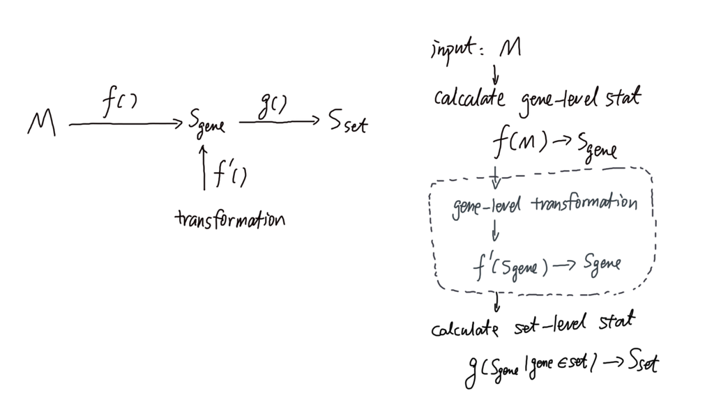

So basically, the calculation of gene-level statistics and set-level statistics can be separated.

We will implement the three independent parts: $f()$, $f'()$ and $g()$.

We first implement the function that calculates gene-level statistics. To make things simple, we assume the matrix is from a two-condition comparison.

- input: an expresion matrix (with condition labels)
- output: a vector of gene-level scores
- method: (t-value, log2fc, …)

```r
# implement t-values as gene-level stat
gene_level = function(mat, condition) {

  #method here...
  return(stat)
}
```

```r
library(matrixStats)
library(genefilter)

# -condition to be a factor, level1 - level2
gene_level = function(mat, condition, method = "tvalue") {

    le = levels(condition)
    l_group1 = condition == le[1]
    l_group2 = !l_group1

    mat1 = mat[, l_group1, drop = FALSE]  # sub-matrix for condition 1
    mat2 = mat[, l_group2, drop = FALSE]  # sub-matrix for condition 2

    if(method == "log2fc") {
        stat = log2(rowMeans(mat1)/rowMeans(mat2))
    } else if(method == "s2n") {
        stat = (rowMeans(mat1) - rowMeans(mat2))/(rowSds(mat1) + rowSds(mat2))
    } else if(method == "tvalue") {
        stat = (rowMeans(mat1) - rowMeans(mat2))/sqrt(rowVars(mat1)/ncol(mat1) + rowVars((mat2)/ncol(mat2)))
    } else if(method == "sam") {
        s = sqrt(rowVars(mat1)/ncol(mat1) + rowVars((mat2)/ncol(mat2)))
        stat = (rowMeans(mat1) - rowMeans(mat2))/(s + quantile(s, 0.1))
    } else if(method == "ttest") {
        stat = rowttests(mat, factor(condition))$p.value
    } else {
        stop("method is not supported.")
    }

    return(stat)
}
```

```r
s = gene_level(expr, condition, method = "s2n")
```

The transformation on gene-level values can actually be integrated as a part of the calculation of gene-level values, i.e. $f'(f())$ can also be thought as a gene-level statistic.

if the gene-level stat is p-values we need to set a cutoff of p to convert to 1/0

binarize() input: is the origial gene-level stat (e.g. p-value) ouput: the values are 1/0

binarize = function(x) ifelse(x < 0.05, 1, 0)

if the gene-level stat is log2fc

binarize = function(x) ifelse(abs(x) > 1, 1, 0)

```r
gene_level = function(mat, condition, method = "tvalue", transform = "none",
  binarize = function(x) x) {

    le = levels(condition)
    l_group1 = condition == le[1]
    l_group2 = !l_group1

    mat1 = mat[, l_group1, drop = FALSE]
    mat2 = mat[, l_group2, drop = FALSE]

    if(method == "log2fc") {
        stat = log2(rowMeans(mat1)/rowMeans(mat2))
    } else if(method == "s2n") {
        stat = (rowMeans(mat1) - rowMeans(mat2))/(rowSds(mat1) + rowSds(mat2))
    } else if(method == "tvalue") {
        stat = (rowMeans(mat1) - rowMeans(mat2))/sqrt(rowVars(mat1)/ncol(mat1) + rowVars((mat2)/ncol(mat2)))
    } else if(method == "sam") {
        s = sqrt(rowVars(mat1)/ncol(mat1) + rowVars((mat2)/ncol(mat2)))
        stat = (rowMeans(mat1) - rowMeans(mat2))/(s + quantile(s, 0.1))
    } else if(method == "ttest") {
        stat = rowttests(mat, factor(condition))$p.value
    } else {
        stop("method is not supported.")
    }

    if(transform == "none") {

    } else if(transform == "abs") {
        stat = abs(stat)
    } else if(transform == "square") {
        stat = stat^2
    } else if(transform == "binary") {
        stat = binarize(stat)
    } else {
        stop("method is not supported.")
    }

    return(stat)
}
```

Let’s test `gene_level()`. Here we still use the p53 dataset which is from the GSEA original paper.

Let’s check the gene-level values:

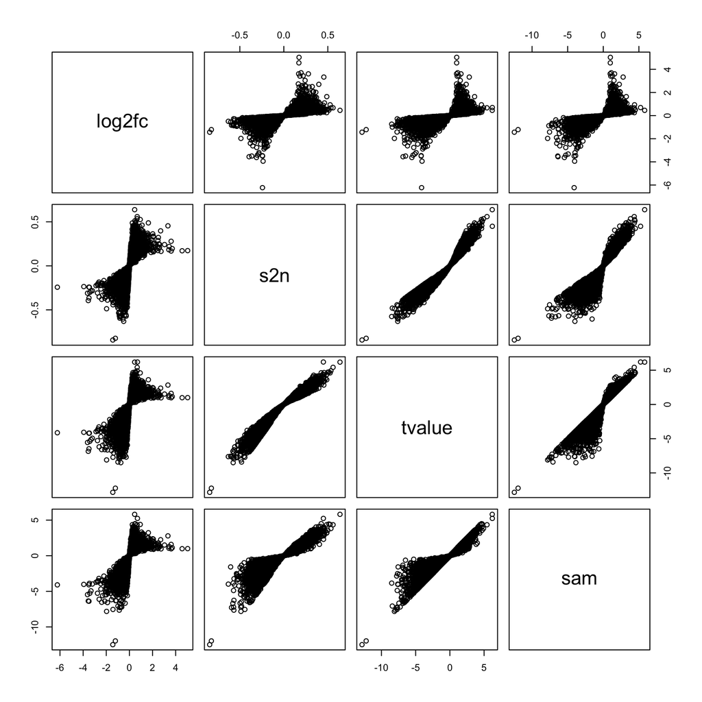

```r
methods = c("log2fc", "s2n", "tvalue", "sam")
lt = lapply(methods, function(x) gene_level(expr, condition, method = x))
names(lt) = methods
pairs(lt)
```

Also we can check number of differential genes (gene level: `ttest` + transform: `binary`). Note a better way is to filter by FDR, but for simplicity, we use p-values directly.

```r
s = gene_level(expr, condition, method = "ttest", transform = "binary",
    binarize = function(x) ifelse(x < 0.05, 1, 0))
table(s)
```

```
## s
##    0    1
## 9394  706
```

If method is set to `log2fc`, then the differential genes can be selected by setting a cutoff for log2 fold change.

```r
s = gene_level(expr, condition, method = "log2fc", transform = "binary",
    binarize = function(x) ifelse(abs(x) > 1, 1, 0))
table(s)
```

```
## s
##    0    1
## 9717  383
```

Implementing `gene_level()` is actually simply.

Next we implement the calculation of set-level statistics. A nature design for the set-level function is to let it accept a vector of gene-level statistics and a gene set represented as a vector of genes, like follows:

```r
# gene_stat: pre-computated gene-level stat for all genes
# geneset: a vector of genes only for a gene set
set_fun = function(gene_stat, geneset) {
    s = gene_stat[geneset] # gene-level stat only for the gene set
    mean(s)
}
```

However, we need to make sure all genes in `geneset` are also in `gene_stat`. A safer way is to test which genes in `gene_stat` are also in `geneset`:

```r
set_fun = function(gene_stat, geneset) {
    s = gene_stat[ names(gene_stat) %in% geneset ]
    mean(s)
}
```

However, recall the set-level can also be calculated based on genes outside of the gene set. Thus the two arguments in `set_level()` are a vector of gene-level statistics for all genes and a logical vector which shows whether genes in the current gene set. In this setting, we can know both which genes are in the set and which genes are not in the set.

```r
# gene_stat: pre-computated gene-level stat for all genes
# l_set: a logical vector where TRUE means in the gene set and FALSE means not in the gene set
# l_set has the same length as gene_stat
set_level = function(gene_stat, l_set, method = "mean") {
    if(!any(l_set)) {
        return(NA)
    }

    if(method == "mean") {
        stat = mean(gene_stat[l_set])
    } else if(method == "sum") {
        stat = sum(gene_stat[l_set])
    } else if(method == "median") {
        stat = median(gene_stat[l_set])
    } else if(method == "maxmean") {
        s = gene_stat[l_set]
        s1 = mean(s[s > 0]) # s1 is positive
        s2 = mean(s[s < 0])  # s2 is negative
        stat = ifelse(s1 > abs(s2), s1, s2)
    } else if(method == "ks") {
        # order gene_stat
        od = order(gene_stat, decreasing = TRUE)
        gene_stat = gene_stat[od]
        l_set = l_set[od]

        s_set = abs(gene_stat)
        s_set[!l_set] = 0
        f1 = cumsum(s_set)/sum(s_set)

        l_other = !l_set
        f2 = cumsum(l_other)/sum(l_other)

        stat = max(f1 - f2)
    } else if(method == "wilcox") {
        stat = wilcox.test(gene_stat[l_set], gene_stat[!l_set])$statistic
    } else if(method == "chisq") {
        # should on work with binary gene-level statistics
        stat = chisq.test(factor(gene_stat), factor(as.numeric(l_set)))$statistic
    } else {
        stop("method is not supported.")
    }

    return(stat)
}
```

Let’s check `set_level()`:

input of `set_level()`:

1. a gene-level scores
2. a logical vector which shows whether the genes are in a set

```r
gene_stat = gene_level(expr, condition)

ln = strsplit(readLines(system.file("extdata", "c2.symbols.gmt", package = "GSEAtutorial")), "\t")
gs = lapply(ln, function(x) x[-(1:2)])
names(gs) = sapply(ln, function(x) x[1])

geneset = gs[["p53hypoxiaPathway"]]
l_set = rownames(expr) %in% geneset
set_level(gene_stat, l_set)
```

```
## [1] -2.076913
```

```r
set_level(gene_stat, l_set, method = "ks")
```

```
## [1] 0
```

Now we can wrap `gene_level()` and `set_level()` into a single function `gsea_tiny()` which accepts the expression and one gene set as input, and it returns the set-level score.

gsea_tiny():

- expression matrix (condition labels)
- a gene set

output: a set-level statistic

gsea_tiny() [ gene_level() + set_level() ]

```r
gsea_tiny = function(mat, condition,
    gene_level_method = "tvalue", transform = "none", binarize = function(x) x,
    set_level_method = "mean", geneset) {

    gene_stat = gene_level(mat, condition, method = gene_level_method,
        transform = transform, binarize = binarize)

    l_set = rownames(mat) %in% geneset

    set_stat = set_level(gene_stat, l_set, method = set_level_method)

    return(set_stat)
}
```

We apply `gsea_tiny()` to the p53 dataset.

```r
gsea_tiny(expr, condition, geneset = geneset)
```

```
## [1] -2.076913
```

We use `wilcox.test()` to calculate the Wilcoxon statistic. Note this function also does a lot of extra calculations. We can implement a function which “just” calculates the Wilcoxon statistic but do nothing else:

The formula is from Wikipedia (https://en.wikipedia.org/wiki/Mann%E2%80%93Whitney_U_test).

Note, to make `wilcox_stat()` faster, we only use maximal 100 data points. It is only for demonstration purpose, you should not use it in real applications.

“outer” calculation

x, y every value in x to every value in y

if length(x) is n, length(y) is m

n*m

`outer()`

m = outer(x, y, “>”)

```r
wilcox_stat = function(x1, x2) {
  if(length(x1) > 100) {
    x1 = sample(x1, 100)
  }
  if(length(x2) > 100) {
    x2 = sample(x2, 100)
  }
  sum(outer(x1, x2, ">"))
}
```

Similarly, we implement a new function which only calculates chi-square statistic:

```r
# x1: a logical vector or a binary vector
# x2: a logical vector or a binary vector
chisq_stat = function(x1, x2) {
    n11 = sum(x1 & x2)
    n10 = sum(x1)
    n20 = sum(!x1)
    n01 = sum(x2)
    n02 = sum(!x2)
    n = length(x1)

    n12 = n10 - n11
    n21 = n01 - n11
    n22 = n20 - n21

    p10 = n10/n
    p20 = n20/n
    p01 = n01/n
    p02 = n02/n

    e11 = n*p10*p01
    e12 = n*p10*p02
    e21 = n*p20*p01
    e22 = n*p20*p02

    stat = (n11 - e11)^2/e11 +
           (n12 - e12)^2/e12 +
           (n21 - e21)^2/e21 +
           (n22 - e22)^2/e22
    return(stat)
}
```

and we change `set_level()` accordingly:

```r
set_level = function(gene_stat, l_set, method = "mean") {
    if(!any(l_set)) {
        return(NA)
    }

    if(method == "mean") {
        stat = mean(gene_stat[l_set])
    } else if(method == "sum") {
        stat = sum(gene_stat[l_set])
    } else if(method == "median") {
        stat = median(gene_stat[l_set])
    } else if(method == "maxmean") {
        s = gene_stat[l_set]
        s1 = mean(s[s > 0])
        s2 = mean(s[s < 0])
        stat = ifelse(s1 > abs(s2), s1, s2)
    } else if(method == "ks") {
        # order gene_stat
        od = order(gene_stat, decreasing = TRUE)
        gene_stat = gene_stat[od]
        l_set = l_set[od]

        s_set = abs(gene_stat)
        s_set[!l_set] = 0
        f1 = cumsum(s_set)/sum(s_set)

        l_other = !l_set
        f2 = cumsum(l_other)/sum(l_other)

        stat = max(f1 - f2)
    } else if(method == "wilcox") {
        stat = wilcox_stat(gene_stat[l_set], gene_stat[!l_set])
    } else if(method == "chisq") {
        # should on work with binary gene-level statistics
        stat = chisq_stat(gene_stat, l_set)
    } else {
        stop("method is not supported.")
    }

    return(stat)
}
```

Next we will adjust `gsea_tiny()` to let it work for multiple gene sets and support random permutation for p-value calculation.

To let is support a list of gene sets, simply change the format of `geneset` variable.

## geneset to be a list of gene sets

```r
# geneset: a list of vectors (gene IDs)
gsea_tiny = function(mat, condition,
    gene_level_method = "tvalue", transform = "none", binarize = function(x) x,
    gene_stat, set_level_method = "mean", geneset) {

    gene_stat = gene_level(mat, condition, method = gene_level_method,
        transform = transform, binarize = binarize)

    # now geneset is a list
    set_stat = sapply(geneset, function(set) {
        l_set = rownames(mat) %in% set

        set_level(gene_stat, l_set, set_level_method)
    })

    return(set_stat)
}
```

Check the new version of `gsea_tiny()`:

```r
ss = gsea_tiny(expr, condition, geneset = gs)
head(ss)
```

```
##          41bbPathway          ace2Pathway acetaminophenPathway
##           -0.2440383           -2.1659276           -1.0293436
##           achPathway        actinYPathway         agpcrPathway
##           -0.2313499           -0.6215275           -0.3424760
```

Now with `gsea_tiny()`, we can also generate the null distribution of the set-level statistics, just by generating random matrices.

```r
# sample permutation
ss_random = list()
for(i in 1:1000) {
    ss_random[[i]] = gsea_tiny(mat, sample(condition), geneset = gs)
}

# or gene permutation
for(i in 1:1000) {
    mat2 = mat
    rownames(mat2) = sample(rownames(mat))
    ss_random[[i]] = gsea_tiny(mat2, condition, geneset = gs)
}
```

A better design is to integrate permutation procedures inside `gsea_tiny()`. We first integrate sample permutation:

```r
# first implement sample permutation
gsea_tiny = function(mat, condition,
    gene_level_method = "tvalue", transform = "none", binarize = function(x) x,
    gene_stat, set_level_method = "mean", geneset,
    nperm = 1000) {

    gene_stat = gene_level(mat, condition, method = gene_level_method,
        transform = transform, binarize = binarize)

    set_stat = sapply(geneset, function(set) {
        l_set = rownames(mat) %in% set

        set_level(gene_stat, l_set, set_level_method)
    })

    ## null distribution
    set_stat_random = list()

    for(i in seq_len(nperm)) {
        condition2 = sample(condition)
        gene_stat = gene_level(mat, condition2, method = gene_level_method,
            transform = transform, binarize = binarize)

        set_stat_random[[i]] = sapply(geneset, function(set) {
            l_set = rownames(mat) %in% set

            set_level(gene_stat, l_set, set_level_method)
        })

        if(i %% 100 == 0) {
            message(i, " permutations done.")
        }
    }

    set_stat_random = do.call(cbind, set_stat_random)

    n_set = length(geneset)
    p = numeric(n_set)
    for(i in seq_len(n_set)) {
        p[i] = sum(set_stat_random[i, ] >= set_stat[i])/nperm
    }

    # the function returns a data frame
    df = data.frame(stat = set_stat,
                    size = sapply(geneset, length),
                    p.value = p)
    df$fdr = p.adjust(p, "BH")

    return(df)
}
```

Let’s have a try. It is actually quite slow to run 1000 permutations.

```r
df = gsea_tiny(expr, condition, geneset = gs)
```

This is the basic procedures of developing new R functions. First we make sure the functions are working, next we optimize the functions to let them running faster or use less memory.

`gsea_tiny()` running with 100 permutations only needs several seconds.

```r
df = gsea_tiny(expr, condition, geneset = gs, nperm = 100)
```

The package **profvis** provides an easy to for profiling.

```r
library(profvis)
profvis(gsea_tiny(expr, condition, geneset = gs, nperm = 100))
```

we can first calculate the relations of genes and sets and later they can be repeatedly used.

```r
gsea_tiny = function(mat, condition,
    gene_level_method = "tvalue", transform = "none", binarize = function(x) x,
    gene_stat, set_level_method = "mean", geneset,
    nperm = 1000) {

    gene_stat = gene_level(mat, condition, method = gene_level_method,
        transform = transform, binarize = binarize)

    # now this only needs to be calculated once
    l_set_list = lapply(geneset, function(set) {
        rownames(mat) %in% set
    })

    set_stat = sapply(l_set_list, function(l_set) {
        set_level(gene_stat, l_set, set_level_method)
    })

    ## null distribution
    set_stat_random = list()

    for(i in seq_len(nperm)) {
        condition2 = sample(condition)
        gene_stat_random = gene_level(mat, condition2, method = gene_level_method,
            transform = transform, binarize = binarize)

        # here we directly use l_set_list
        set_stat_random[[i]] = sapply(l_set_list, function(l_set) {
            set_level(gene_stat_random, l_set, set_level_method)
        })

        if(i %% 100 == 0) {
            message(i, " permutations done.")
        }
    }

    set_stat_random = do.call(cbind, set_stat_random)

    n_set = length(geneset)
    p = numeric(n_set)
    for(i in seq_len(n_set)) {
        p[i] = sum(set_stat_random[i, ] >= set_stat[i])/nperm
    }

    df = data.frame(stat = set_stat,
                    size = sapply(geneset, length),
                    p.value = p)
    df$fdr = p.adjust(p, "BH")

    return(df)
}
```

Now it is faster for 1000 permutations:

```r
df = gsea_tiny(expr, condition, geneset = gs)
```

To support gene permutation, we only need to permute the gene-level statistics calculated from the original matrix. Note we also move position of `geneset` argument to the start of the argument list because it is a must-set argument.

```r
# next we implement gene permutation
gsea_tiny = function(mat, condition, geneset,
    gene_level_method = "tvalue", transform = "none", binarize = function(x) x,
    gene_stat, set_level_method = "mean",
    nperm = 1000, perm_type = "sample") {

    gene_stat = gene_level(mat, condition, method = gene_level_method,
        transform = transform, binarize = binarize)
    l_set_list = lapply(geneset, function(set) {
        rownames(mat) %in% set
    })

    set_stat = sapply(l_set_list, function(l_set) {
        set_level(gene_stat, l_set, set_level_method)
    })

    ## null distribution
    set_stat_random = list()

    for(i in seq_len(nperm)) {

        if(perm_type == "sample") {
            condition2 = sample(condition)
            gene_stat_random = gene_level(mat, condition2, method = gene_level_method,
                transform = transform, binarize = binarize)

            set_stat_random[[i]] = sapply(l_set_list, function(l_set) {
                set_level(gene_stat_random, l_set, set_level_method)
            })
        } else if(perm_type == "gene") {
            gene_stat_random = sample(gene_stat)

            set_stat_random[[i]] = sapply(l_set_list, function(l_set) {
                set_level(gene_stat_random, l_set, set_level_method)
            })
        } else {
            stop("wrong permutation type.")
        }

        if(i %% 100 == 0) {
            message(i, " permutations done.")
        }
    }

    set_stat_random = do.call(cbind, set_stat_random)

    n_set = length(geneset)
    p = numeric(n_set)
    for(i in seq_len(n_set)) {
        p[i] = sum(set_stat_random[i, ] >= set_stat[i])/nperm
    }

    df = data.frame(stat = set_stat,
                    size = sapply(geneset, length),
                    p.value = p)
    df$fdr = p.adjust(p, "BH")

    return(df)
}
```

Let’s check:

```r
set.seed(123)
df1 = gsea_tiny(expr, condition, geneset = gs, perm_type = "sample")
df2 = gsea_tiny(expr, condition, geneset = gs, perm_type = "gene")
```

```r
df1 = df1[order(df1$p.value), ]
df2 = df2[order(df2$p.value), ]
head(df1)
```

```
##                     stat size p.value   fdr
## rasPathway     1.1681777   23   0.001 0.522
## ngfPathway     0.9281860   19   0.005 1.000
## igf1Pathway    0.8149574   20   0.008 1.000
## tall1Pathway   1.1008992   15   0.008 1.000
## insulinPathway 0.7048546   21   0.011 1.000
## anthraxPathway 2.1056600    2   0.015 1.000
```

```r
head(df2)
```

```
##                         stat size p.value fdr
## cdc25Pathway      1.55759420    9       0   0
## igf1Pathway       0.81495735   20       0   0
## proteasomePathway 0.83295915   21       0   0
## rasPathway        1.16817766   23       0   0
## tall1Pathway      1.10089916   15       0   0
## INSULIN_2F_UP     0.05898347  235       0   0
```

Note, above settings can only detect the up-regulated gene sets.

Great! If we think each combination of gene-level method, gene-level transformation and set-level method is *a GSEA method*, then our `gsea_tiny()` actually already support many GSEA methods! The whole functionality only contains ~180 lines of code (https://gist.github.com/jokergoo/e8fff4a57ec59efc694b9e730da22b9f).

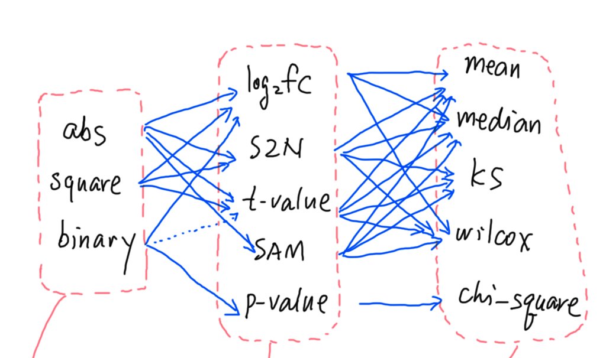